# report

Author

Julianna Mack & Ben Hopkins

Published

3/17/25

# Premium Growth Model Annual Report: 2025

##### Last Updated: Thursday Mar 27, 2025

##### Author: Julianna Mack & Ben Hopkins

## Introduction

The Congressional Budget Office uses the premium growth model (PGM) to project health expenditures per privately insured person through the 10-year baseline period. The PGM generates factors used in CBO’s health insurance simulation model, HISIM2, to project increases in health spending, employment-based insurance (EBI) premiums, and employer contributions to health reimbursement accounts (HRAs) and health savings accounts (HSAs). The factors are also used to project growth in plan characteristics such as maximum out-of-pocket spending for EBI plans and for nongroup plans, and deductibles for nongroup plans. Additionally, the output of the PGM is used in HISIM2 to project growth in premiums for nongroup plans. The PGM’s output is also used by the Joint Committee on Taxation and is used for other purposes by CBO.

The PGM is updated by CBO each year, and those updates are incorporated into CBO’s spring baselines. The most recent PGM projections are for the spring 2025 baseline, and the previous projections were for the spring 2024 baseline. One way to compare the two sets of projections is to focus on the projected expenditures for health care services per capita by insurers in the last year they share in common (2034). Looking at the figure below, the 2025 updates to the PGM have increased projected expenditures per capita in 2034 by about $1,448 (12.9%). CBO now projects higher per capita expenditures than it did last year after incorporating newly available historical data indicating rapid premium growth in 2022 and 2023 and consulting with stakeholders, who suggested that high growth rates are likely to persist through at least 2025. The surge in expenditures among the privately insured partly reflects the adoption of costly pharmaceuticals, most notably GLP-1s, but it also reflects broader growth in spending on hospital care and mental health care. CBO has also significantly updated the specification of the regression model. Those technical updates have smoothed the path of projected premium growth but did not significantly alter the projected level of expenditures at the end of the period.

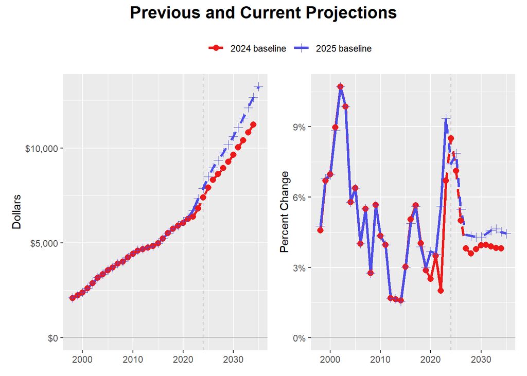

## Overview of the Premium Growth Model (PGM) and Updates for the 2025 Baseline

The PGM is a set of two time-series regression models used to project growth in health expenditures per privately insured person; those projections serve as the basis for premiums in CBO’s modeling. Health expenditures, in this context, include amounts paid by the health insurer and administrative expenses incurred by the insurer and exclude cost sharing paid by the patient at the point of service and out-of-pocket spending on noncovered services. Private health insurance includes EBI plans and nongroup plans and excludes medigap plans, Medicare Advantage plans, and Medicaid managed care plans. The first of the two models, the current-year model, projects expenditures for the first year of the forecast window using recent data on premiums from surveys. The second, the primary model, projects expenditures for the remainder of the forecast window using an autoregressive term and CBO’s macroeconomic forecast. The 2025 PGM uses growth in real income to project real health expenditures per privately insured person. The projected real health expenditures are then combined with projected prices (PCEMED) to produce nominal projected expenditures per capita.

### Data

The key source for historical estimates of expenditures per capita is the National Health Expenditure Accounts (NHEA).[^1] CBO modifies those data in two ways. First, estimated medigap plan expenditures and medigap enrollment are removed. Second, expenditures are adjusted to remove the effects of onetime events that significantly affected expenditure growth but should not be reflected in the long-term equilibrium–namely the establishment of health insurance marketplaces under the Affordable Care Act[^2] and the COVID-19 pandemic.

The ACA marketplaces significantly altered the individual insurance market by expanding coverage and introducing new subsidies, but their impact on expenditure growth rates varied over time. In the initial years, there was a surge in enrollment, particularly among previously uninsured individuals with preexisting health care needs, leading to a temporary spike in expenditures. Over time, as the market stabilized and risk pools adjusted, expenditure growth rates may have normalized, which is why CBO views the establishment of those marketplaces more as a onetime shock than a permanent change in trend.

CBO creates two versions of the historical and projected expenditures. One version includes an adjustment to exclude any growth due to changes in the age and sex composition of the privately insured population, and the other version does not include that adjustment. HISIM2 uses premium growth projections that exclude the effects of demographic changes because the microsimulation model implicitly accounts for those changes while projecting insurance coverage.[^3] To create the age- and sex-adjusted version, CBO uses the Current Population Survey (CPS) to estimate, for each historical year, the share of the privately insured population with each combination of single year of age and sex. CBO then applies the spending patterns estimated by Dale H. Yamamoto (2013) to estimate the change in expenditures attributable to demographic changes and creates an annual index used to scale estimates of health expenditures per privately insured person.[^4]

Other inputs to the model include [CBO’s historical data and economic projections](https://www.cbo.gov/data/budget-economic-data#11). Those variables include the total U.S. population (including members of the armed forces overseas and the institutionalized population), personal disposable income (PDI), the personal consumption expenditures price index for consumer goods (PCE). For the PGM, CBO also uses historical and projected values of the personal consumption expenditures price index for medical spending (PCEMED).

CBO adjusts both the expenditure and income variables during the pandemic period because the pandemic resulted in higher PDI and a temporary decrease in utilization of health care services. That decrease in utilization resulted in low expenditure growth in 2020 and high expenditure growth in 2021 as utilization rebounded. Without adjustment, those outliers may result in less accurate coefficient estimates and affect the projections through the autoregressive terms in the model. CBO adjusts income because stimulus payments in 2021 and 2022 provided a temporary boost to income that was slowly spent down over subsequent years. Less significantly, many people realized large capital gains in 2021 because of excess liquidity from the 2020 stimulus checks and other pandemic-related fiscal measures. CBO smoothed those fluctuations in income under the assumption that health spending responds more to permanent changes in income than temporary ones over the medium run.

For the spring 2025 baseline, CBO made the following changes to its treatment of the data:

| Factor | Spring 2024 | Spring 2025 |
| --- | --- | --- |
| COVID Adjustment: Expenditures | Fixed expenditure growth to 2.4% (2020) and 2.5% (2021) to align with survey estimates of premium growth. | Fixed 2020 expenditures at the midpoint of 2019 and 2021 expenditures. |
| COVID Adjustment: PDI | None | Smoothed PDI to account for the slow draw down of stimulus income in 2021 and 2022 and surplus capital gains in 2021. |
| medigap backcasting[^5] | Backcast medigap spending to 1987 using Consumer Price Index for All Urban Consumers: Medical Care | Backcast medigap spending to 1987 using Medicare expenditure per capita |

### Methods

The PGM consists of two models: the current-year model and the primary model. The current year model is used to project real health expenditures per capita in the first year of the forecast window. The primary model is used to project health expenditures for the remaining years of the window. As the primary model is an autoregressive model, the projection of the current-year model is an input to the projection of the primary model.

The current-year regression model calculates a preliminary estimate of growth in private health expenditures per capita from 2023 to 2024. That model is estimated using historical data through 2023 on growth in premiums for EBI plans and then used to project growth in expenditures in 2024. This model is necessary because the last year of historical data from the NHEA is 2023, but other sources provide useful information on growth in private premiums from 2023 to 2024 and from 2024 to 2025. The sources for this regression model are the Bureau of Labor Statistics’ (BLS’s) producer price index (PPI) for comprehensive medical insurance plans, and KFF’s Employer Health Benefits Survey (EHBS).[^6]

For 2025 and beyond, health expenditures per capita are projected using the primary model. The primary model is an autoregressive model of expenditure growth that includes projections of PDI and, new for the spring 2025 baseline, medical prices (PCEMED).[^7] Thus, the model tends to revert from expenditure growth in the first year of the window to a long-term equilibrium while tracking projected changes in income and medical prices. Although the historical NHEA data extend into the 1980s, CBO excludes data prior to 1999 when estimating the model, as expenditure growth in the 1990s was driven by the rise of and subsequent backlash against health maintenance organizations (HMOs). CBO believes that the more distant historical period is less applicable to projecting premium growth over the next decade.

To further refine its estimates, CBO conducted a series of stakeholder interviews and reviewed data from other sources including the Federal Employees Health Benefits program. Stakeholders were selected to represent the views of the insurance industry, actuaries, and employers in their role as purchasers of health benefits. Drawing from those sources, CBO applies an adjustment factor to the current-year estimate (growth from 2023 to 2024), and the first year of the projection (growth from 2024 to 2025).

The following table summarizes updates to the PGM methodology applied to the spring 2025 baseline:

[output not shown]

## Changes to the Projection

To facilitate the comparison of the spring 2024 and spring 2025 projections, changes in the estimates are decomposed into a series of steps:

1. **Updating the Historical Data:** Changes resulting from updating the data on expenditures per capita (and our adjustments to them) and the demographic composition of the privately insured population. The macroeconomic forecast and the model specification and coefficients are held fixed.
2. **Updating the Macroeconomic Forecast:** Changes resulting from updating the macroeconomic forecast. The model specification and coefficients are held fixed.
3. **Updating the Coefficients of the Previous Model Specification:** Changes resulting from updating the coefficient estimates using the model specification from the previous baseline. The model specification is held fixed.
4. **Updating the Model Specification:** Changes resulting from updating the model specification.
5. **Adjusting the Near-Term Projections:** Adjustments are made to the current-year estimate and the estimate for the first year of the projection. These adjustments reflect stakeholder input and data not otherwise formally incorporated in the projection.

### Step 1: Updating the Historical Data

As shown in the chart below, CBO’s projection of expenditures per capita in 2034 has increased by $839 (7.5%) since last year because of changes in the historical data. In the historical data, values for expenditure growth increased in 2020, 2022, and 2023. Those changes yield higher premium growth in 2024 but a similar path thereafter. The difference in 2020 is due to the aforementioned change in CBO’s method for adjusting expenditure growth during the first year of the pandemic, when expenditures fell sharply relative to premiums. The difference in 2022 and 2023 reflects (1) an upward revision to the NHEA data for 2022 and (2) a new data point in 2023. Both the revised 2022 and new 2023 premium growth rates are higher than the rates estimated from survey data in those years.

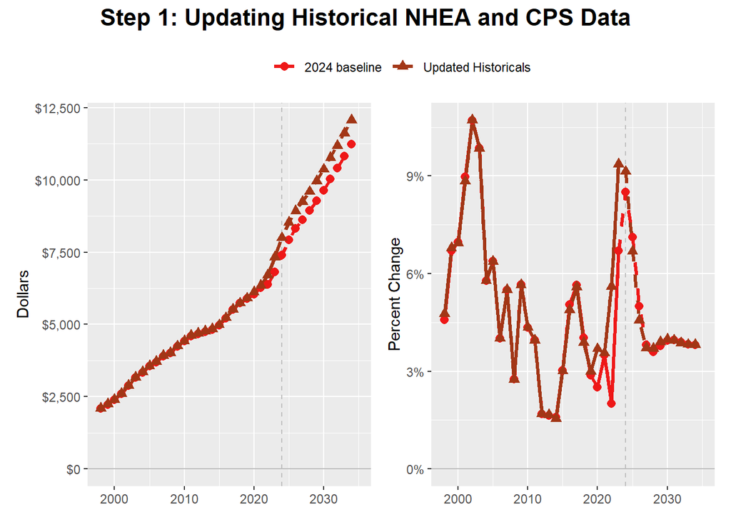

### Step 2: Updating the Macroeconomic Forecast

The updates to CBO’s PDI forecast had a negligible effect on the projections of health expenditure growth. This step includes the adjustments to the PDI forecast in the early 2020s to account for drawn-out spending of stimulus payments received in 2021 and 2022 and excess capital gains in 2021. The effect of updating the PDI forecast is minor because the estimated coefficient on the three-year growth rate of PDI per capita in the spring 2024 baseline model was very small: A 10 percentage-point increase in the three-year PDI per capita growth rate yields only a 0.2 percentage-point increase in the health expenditures per capita growth rate. The change in PDI was negligible, as the previous specification placed less emphasis on it.

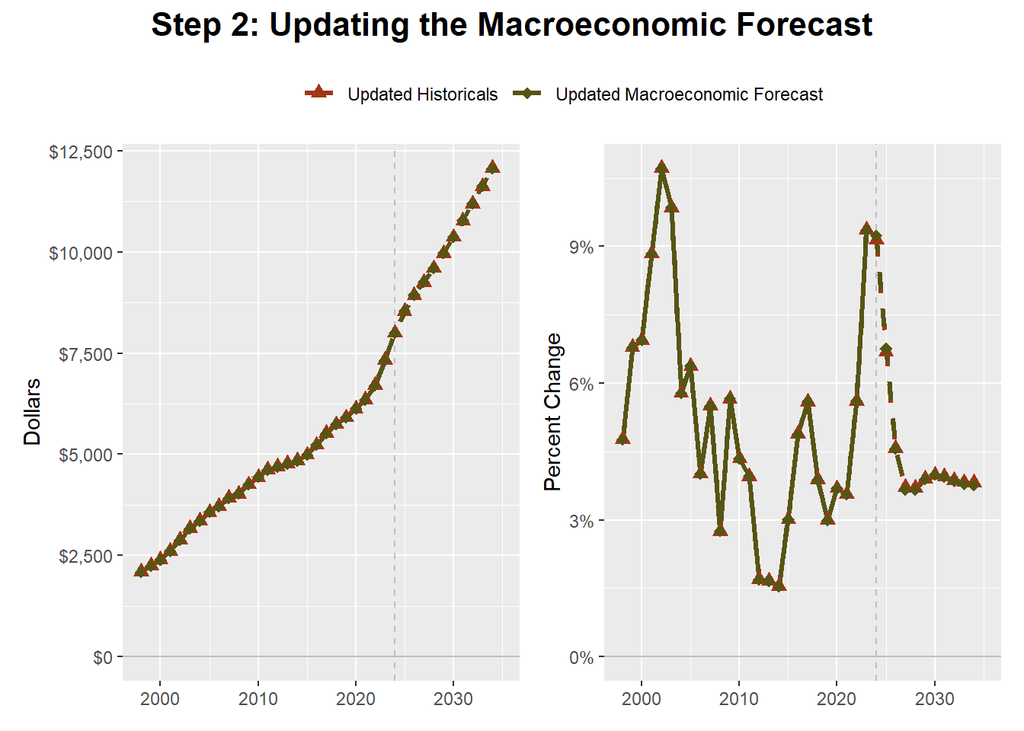

### Step 3: Updating the Coefficients of the Previous Model Specification

In Step 3, CBO reestimates the spring 2024 specification using the updated input data and projects expenditure growth using the updated coefficient estimates. In the updated estimates, the effect of PDI roughly doubled, and the magnitude of the coefficients on the first and second autoregressive terms (which are positive and negative, respectively) increased. Those changes yield a projected peak in expenditure growth in 2024, greater oscillation around the equilibrium thereafter, and, overall, higher expenditures in 2033.

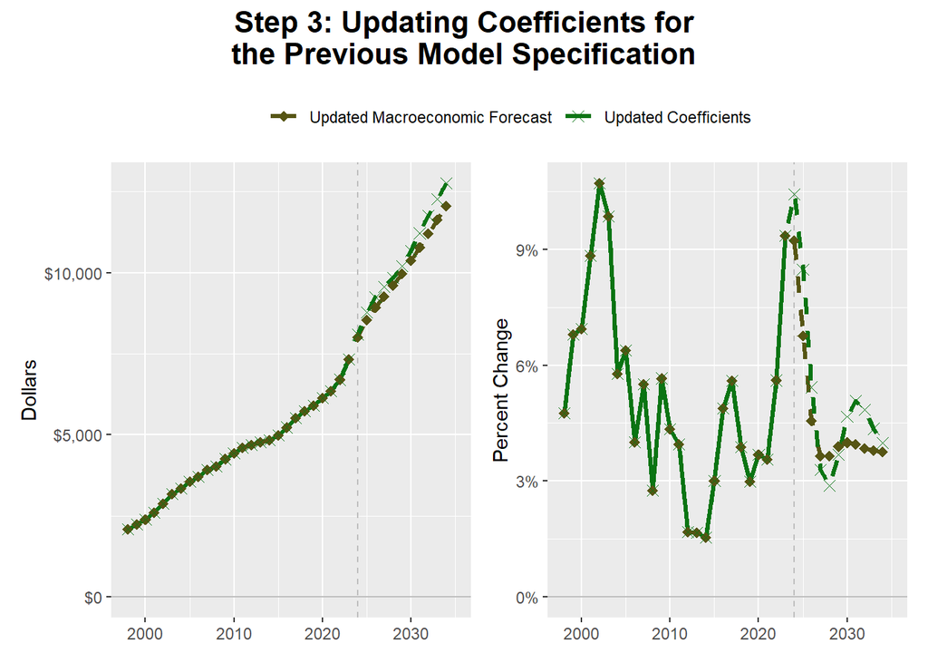

### Step 4: Updating the Model Specification

The next step in updating the projection is estimating the new model specification. One update is to define a formal regression model (the “current-year” model) for growth in the first year of the projection (from 2023 to 2024). That model is a simple regression of expenditure growth on survey estimates of premium growth from BLS and KFF’s EHBS. The PGM specification for 2025 was also updated in several key ways.

First, the projection is now based on real health expenditures per capita, rather than nominal health expenditures per capita, and the projections of real health expenditures are combined with a projected price index (PCEMED) to yield projected nominal values. Second, the regression now includes real PDI as a predictor, rather than nominal PDI. Those two changes reflect a conceptual framework in which growth in real income drives growth in real health expenditures, and price growth is modeled separately.

Third, growth in PDI is now measured over six rather than three years. That allows for longer delays in the process by which real income leads to changes in real health expenditures. CBO uses a six-year lag because a literature review by the agency identified income as a primary determinant of health spending growth in the medium term and model validation statistics indicated that long-term growth rates are a better predictor of health spending than short-term growth rates or distributed lag models.

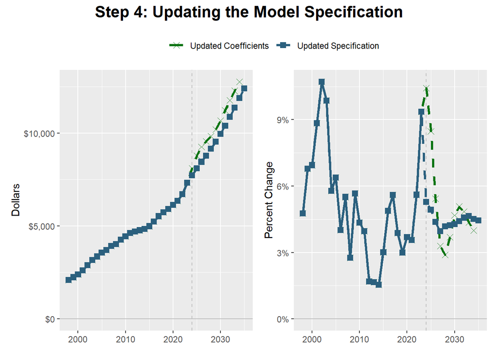

### Step 5: Adjusting the Near-Term Projections

[figure not shown]

### Additional Projections: Health Care Expenditures Per Capita Without Demographic Adjustment

CBO also produces projections of health expenditures per capita that incorporate changes in the age and sex composition of the privately insured population. The agency generates those predictions by estimating the same current-year and primary models using data that have not been adjusted for demographics. The difference between the adjusted and unadjusted projections (in log differences) represents the implied change in health expenditures per capita due to demographic changes. As growth in the unadjusted projections exceeds growth in the adjusted projections, CBO is implicitly forecasting that demographic changes will contribute positively to growth in health expenditures per capita over the next 10 years. That expected trend is consistent with the continued aging of the U.S. population.

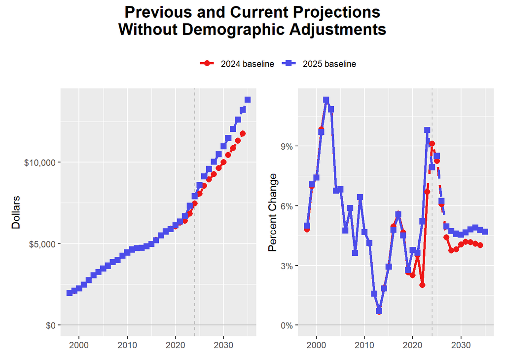

## Glossary

- **Health expenditures per capita**

The premium growth model uses data on private enrollment and expenditures from Table 21 of the National Health Expenditure Accounts to create private per capita premiums. National health expenditures equal health consumption expenditures plus the sum of medical-sector purchases of structures and equipment and expenditures for noncommercial medical research (investment).

Private Per Capita Premiums = Total Private Health Insurance Expenditures / Total Private Health Insurance Enrollment

Sources: [Centers for Medicare & Medicaid Services, “Historical”](https://www.cms.gov/data-research/statistics-trends-and-reports/national-health-expenditure-data/historical) (accessed January, 2025), and [Bureau of Economic Analysis, NIPA Handbook: Concepts and Methods of the U.S. National Income and Product Accounts, Chapter 5](https://www.bea.gov/resources/methodologies/nipa-handbook) (December 2024), .

- **Personal consumption expenditures price index for medical spending (PCEMED)**

The premium growth model uses PCEMED to measure medical prices and deflate nominal private health insurance expenditures per capita. Historical values of PCEMED are taken from the Bureau of Economic Analysis’s (BEA’s) National Income and Products Accounts (NIPAs), and projections are done by CBO.

PCEMED has three subcomponents:

- PCE: Therapeutic Appliances & Equipment Price Index , also known as PCDMED, which comprises 2 percent of PCEMED
- PCE: Pharmaceutical & Other Medical Products Price Index, also known as PCNMED, which comprises 17 percent of PCEMED
- PCE: Health Care Services, also known as PCSMED, which comprises 81 percent of PCMED

CBO’s projections of PCDMED and PCNMED are based on simple autoregressive moving average models. The agency’s projections of PCSMED, which makes up the bulk of the PCEMED index, involve an iterative process within CBO between MAD and the Budget Analysis Division.

Key steps for projecting PCSMED include:

1. Forecasting producer price indexes (PPIs) for inpatient care, outpatient care, and physician care
2. Using those PPIs to forecast PCE price indexes for hospital care and physician care
3. Aggregating the resulting PCE indexes along with the employment cost index (ECI) to forecast the overall PCE for medical services

Equation for PCSMED (as of spring 2024), where the Greek letter pi represents growth in a price index, beta represents an estimated coefficient, and epsilon is an error term:

$$\pi_t^{\text{PCSMED}} = \beta_1\pi_{t-1}^{\text{PCSMED}} + \beta_2\pi_t^{\text{PCE for hospital care}} + \beta_3\pi_t^{\text{PCE for physician care}} + \beta_4\text{ECI}_t + \epsilon_t$$

The following table describes some of the key differences between PCEMED and the Consumer Price Index: Medical care (CPI-M).

| Factor | PCEMED | CPI-M |
| --- | --- | --- |
| Scope | Includes direct payments made by consumers and third-party payments made on behalf of consumers | Only includes out-of-pocket expenditures made by consumers |
| Construction | Fisher price index | Laspeyres index |
| Data sourcing | Sector-specific PPIs and sector-specific CPIs | Consumer surveys |
| Usage as medical care deflator | Adjusting for purchasing power changes on personal consumption expenditures | Adjusting for purchasing power changes in out-of-pocket expenditures |

- **Personal consumption expenditures price index for consumer goods (PCE)**

The premium growth model uses PCE to deflate growth in personal disposable income. This series is taken and processed from the Bureau of Economic Analysis’s National Income and Products Accounts (NIPA) data. In the NIPAs, final consumption expenditures by households or nonprofit institutions serving households represent the portion of PCE for services provided to households without explicit charge, like the value of nonprofit college education exceeding tuition and fees. It equals their gross output, calculated as current operating expenses (excluding capital investments) minus sales to households and other sectors and the value of investment goods.

Source: Congressional Budget Office, [*Historical Data and Economic Projections*](https://www.cbo.gov/data/budget-economic-data#11) (accessed January, 2025).

- **Personal Disposable Income (PDI)**

The PGM uses real PDI, meaning nominal PDI divided by PCE, as an explanatory variable for real premium growth. PDI is the income that is left after people pay their taxes, and so is also known as after-tax income.

Source: Congressional Budget Office, [*Historical Data and Economic Projections*](https://www.cbo.gov/data/budget-economic-data#11) (accessed January, 2025); and Bureau of Economic Analysis, [*Income & Saving*](https://www.bea.gov/resources/learning-center/what-to-know-income-saving) (accessed January, 2025).

- **Yamamoto index**

Dale H. Yamamoto measured health care spending among a sample of enrollees in commercial health insurance, by single year of age and sex. Those spending measures are combined with enrollment data from the Current Population Survey and are used to estimate the role of demographic changes in the historical trends in private health expenditures per capita.

Source: Dale H. Yamamoto. [*Health Care Costs—From Birth to Death*](https://www.soa.org/resources/research-reports/2013/research-health-care-birth-death/) (2013).

## Footnotes

[^1]: For definitions of terms used in this report, please refer to the Glossary at the end of this report.
[^2]: The growth rate is increased by half a percentage point in 2013 and decreased by half a percentage point in 2014 to account for the effects of the Affordable Care Act.
[^3]: For the Joint Committee on Taxation, CBO produces a version of the projections that does not account for demographic changes. For that purpose, the series includes all other modifications discussed in this report and is projected using the same model specification.
[^4]: Dale H. Yamamoto. [*Health Care Costs—From Birth to Death*](https://www.soa.org/resources/research-reports/2013/research-health-care-birth-death/) (2013).
[^5]: The NHEA estimates of medigap spending per enrollee begin in 2001.
[^6]: See Bureau of Labor Statistics, [*PPI industry data for Direct health and medical insurance carriers-Comprehensive medical service plans, not seasonally adjusted*](https://data.bls.gov/timeseries/PCU524114524114101) (accessed January, 2025). For more information on the EHBS, see Gary Claxton, Matthew Rae, Aubrey Winger, and Emma Wager, [*Employer Health Benefits: 2024 Annual Survey*](https://files.kff.org/attachment/Employer-Health-Benefits-Survey-2024-Annual-Survey.pdf) (October 2024).
[^7]: For convenience, the model includes the PCEMED index as an explanatory variable with a fixed coefficient of one. That approach is equivalent to estimating the model and generating predictions in real terms then multiplying the predictions by PCEMED to convert them to nominal terms.